# projekt2

Julia Gołębiowska

26/05/2022

## 1. Exploracja

```r
#read
library(data.table)
x_train = as.data.frame(fread("X_train.csv.gz"))
x_test = as.data.frame(fread("X_test.csv.gz"))
y_train = as.data.frame(fread("y_train.csv.gz"))
```

Dane mają 9000 zmiennych. Są 3794 obserwacje w zbiorze treningowym i 670 obserwacji w zbiorze treningowym.

```r
head(x_train)
```

|  | LINC01128 | NOC2L | HES4 | ISG15 | AGRN | C1orf159 | TNFRSF18 | TNFRSF4 | SDF4 | B3GALT6 | SCNN1D | PUSL1 | INTS11 | CPTP | DVL1 | CCNL2 | SSU72 | AL645728.1 | AL691432.2 | MIB2 | MMP23B | CDK11B | CDK11A | GNB1 | PRKCZ | AL590822.2 | FAAP20 | SKI | MORN1 | … |
| --- | --- | --- | --- | --- | --- | --- | --- | --- | --- | --- | --- | --- | --- | --- | --- | --- | --- | --- | --- | --- | --- | --- | --- | --- | --- | --- | --- | --- | --- | --- |
| 1 | 0 | 0.0000000 | 0 | 0.9530905 | 0 | 0 | 0 | 0 | 0 | 0 | 0 | 0 | 0 | 0 | 0 | 0.0000000 | 1.432086 | 0 | 0 | 0 | 0 | 0 | 0.0000000 | 0 | 0 | 0.0000000 | 0.9530905 | 0 | 0 | … |
| 2 | 0 | 0.0000000 | 0 | 0.0000000 | 0 | 0 | 0 | 0 | 0 | 0 | 0 | 0 | 0 | 0 | 0 | 0.0000000 | 0.000000 | 0 | 0 | 0 | 0 | 0 | 0.0000000 | 0 | 0 | 0.0000000 | 0.7352883 | 0 | 0 | … |
| 3 | 0 | 1.1452906 | 0 | 0.0000000 | 0 | 0 | 0 | 0 | 0 | 0 | 0 | 0 | 0 | 0 | 0 | 0.0000000 | 0.000000 | 0 | 0 | 0 | 0 | 0 | 0.0000000 | 0 | 0 | 0.0000000 | 0.0000000 | 0 | 0 | … |
| 4 | 0 | 0.0000000 | 0 | 0.0000000 | 0 | 0 | 0 | 0 | 0 | 0 | 0 | 0 | 0 | 0 | 0 | 0.0000000 | 0.000000 | 0 | 0 | 0 | 0 | 0 | 0.7451485 | 0 | 0 | 0.0000000 | 0.0000000 | 0 | 0 | … |
| 5 | 0 | 0.5644676 | 0 | 0.0000000 | 0 | 0 | 0 | 0 | 0 | 0 | 0 | 0 | 0 | 0 | 0 | 0.5644676 | 0.000000 | 0 | 0 | 0 | 0 | 0 | 0.0000000 | 0 | 0 | 0.0000000 | 0.0000000 | 0 | 0 | … |
| 6 | 0 | 0.0000000 | 0 | 0.8929155 | 0 | 0 | 0 | 0 | 0 | 0 | 0 | 0 | 0 | 0 | 0 | 0.0000000 | 0.000000 | 0 | 0 | 0 | 0 | 0 | 0.0000000 | 0 | 0 | 0.8929155 | 0.0000000 | 0 | 0 | … |

```r
head(y_train)
```

|  | CD36 |
| --- | --- |
| 1 | 0.0000000 |
| 2 | 2.1832790 |
| 3 | 0.0000000 |
| 4 | 0.2991487 |
| 5 | 0.0000000 |
| 6 | 0.0000000 |

```r
sum(is.na(x_train)) #check comletness
```

```
## [1] 0
```

```r
sum(is.na(x_test)) #check comletness
```

```
## [1] 0
```

Dane są kompletne

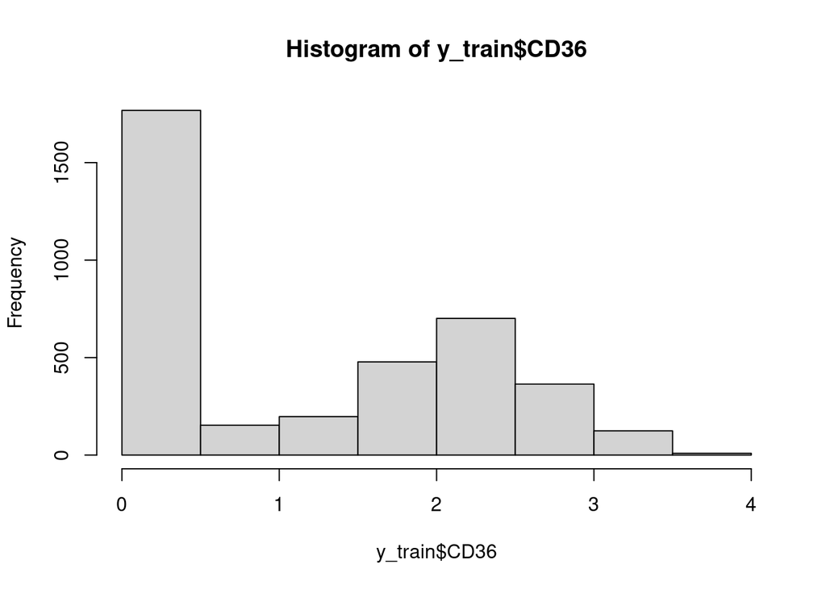

```r
mean_y = mean(y_train$CD36)
median_y = median(y_train$CD36)
variance_y = var(y_train$CD36)
hist(y_train$CD36)
```

Zbiór obserwacji zmiennej objaśnianej ma średnią: 1.1453633, medianę: 0.9147127 i wariancje: 1.2243656. Histogram zmiennej objaśnianej wskazuje, że gdyby w danych nie było tak dużo wartości 0, to rozkład tej zmiennej byłby zbliżony do normalnego. Poniżej możemy zobaczyć heatmapę korelacji dla 250 najbardziej skorelowanych zmiennych ze zmienną objaśnianą. Możemy zauważyć, że istnieją grupy zmiennych bardzo ze sobą skorelowanych.

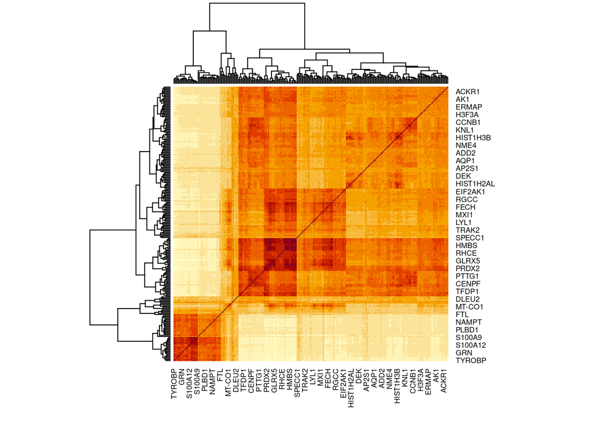

```r
#choose 250 the most correlated with y_train
corr <- apply(x_train[,1:9000], 2, cor, y_train$CD36)
#calculate correlation between chosen variables
order_corr <- unlist(order(corr, decreasing=TRUE))[1:250]
p.corr <- cor(x_train[,order_corr])
heatmap(p.corr, scale = "none")
```

## 2. Elastic Net

Elastic Net - to metoda regresji linniowej, która dobiera parametry modelu linniowego ($\beta$), poprzez minimalizacje wyrażenia (*)

$RSS = \sum_{x = i}^{n} ( y_{i} - (\beta_{0} + \sum_{x = j}^{p}(\beta_{j}x_{ij})))^2$

(*) $RSS + \lambda_{1} \sum_{x = j}^{p} |\beta_{j}| + \lambda_{2} \sum_{x = j}^{p} \beta_{j}^2$

Możemy zauważyć, że model ten łączy metody regularyzacji regresji lasso i ridge. Hiperparametrami w tej metodzie są $\lambda_{1}$ i $\lambda_{2}$ nazywane parametrami sterującym (ang. tuning parameter). W szczególnym przypadku gdy $\lambda_{1} = 0$ otrzymujemy wyrażenie minimalizowane w eotodzie rigde, a gdy $\lambda_{2} = 0$ to otrzymujemy z koleji wyrażenie minimalizowane w metodzie lasso. Metoda Elastic Net łączy zalety metod lasso i ridge. Dla niektórych skorelowanych zmiennych może przypoządkować wspólczynniki modelu do zera lub też je zrównać do zera. Pozwala to na kompromis między modelem bardzo prostym a skomplikowanym, szczególnie dla dużych danych i trudno intrepretowalnych z dużą korelacją niektórych zmiennych (takich jak w tym zadaniu). (żródla: https://www.youtube.com/watch?v=1dKRdX9bfIo, https://en.wikipedia.org/wiki/Elastic_net_regularization)

Ponieważ dane są duże to zdecydowałam się na liczbę podzbiorów walidacji krzyżowej równej 5. Taki podział pozwala na dość szybką estymacje parametrów, a jednocześnie zachowawanie dużego zbioru treningowego (80% wszystkich danych).

```r
x = 5
split <- cut(1:nrow(x_train), x, labels = F)
split <- sample(split)

library(glmnet)
```

```r
library(MDplot)
list_folds_test=list()
list_folds_train=list()
for (i in 1:x) {
  train <- which(split != i)
  alpha =c(0, 0.1, 0.5, 0.75, 1)
  lambda= c(0.001, 0.01, 0.1, 1)
  matrix_parametrs_test <-matrix(0,length(alpha),length(lambda), dimnames = list(alpha,lambda))
  matrix_parametrs_train <-matrix(0,length(alpha),length(lambda), dimnames = list(alpha,lambda))
    for (a in  1:length(alpha)){
    for (l in 1:length(lambda)){
  model <- glmnet(x=x_train[train,,drop=TRUE],  y=y_train[train,], alpha = alpha[a], lambda = lambda[l])
  prediction <- predict(model, newx=as.matrix(x_train), 'response')
  prediction_train <- prediction[train]
  prediction_test <- prediction[-train]
#count RMSD and store result in matrix
  matrix_parametrs_train[a,l]<-sqrt(sum((prediction_train - y_train$CD36[train])^2)/length(train))
  matrix_parametrs_test[a,l]<- sqrt(sum((prediction_test - y_train$CD36[-train])^2)/(nrow(y_train)-length(train)))
           }   }
list_folds_test[[i]] <- matrix_parametrs_test
list_folds_train[[i]]<- matrix_parametrs_train
}
```

W celu porówania wyników uśredniamy je dla każdego zbioru wykorzystanego podczas walidacji krzyżowej.

```r
#count mean
matrix_parametrs_test_mean <- Reduce("+", list_folds_test)/x
matrix_parametrs_train_mean <- Reduce("+", list_folds_train)/x
matrix_parametrs_test_mean
```

```
##          0.001      0.01       0.1         1
## 0    1.0405444 0.5007834 0.4420660 0.3717430
## 0.1  0.5084571 0.4172635 0.3422538 0.4525213
## 0.5  0.4556035 0.3576175 0.3825393 0.8839886
## 0.75 0.4357420 0.3476582 0.4082195 1.0974049
## 1    0.4227566 0.3438419 0.4358969 1.1067497
```

```r
matrix_parametrs_train_mean
```

```
##            0.001        0.01        0.1         1
## 0    0.001530379 0.002998916 0.02571067 0.1292543
## 0.1  0.007055990 0.062233374 0.27009600 0.4468642
## 0.5  0.032224162 0.197035782 0.37227649 0.8827482
## 0.75 0.046610833 0.241336841 0.40211832 1.0968959
## 1    0.060108928 0.269868304 0.43142564 1.1063071
```

```r
#save errors for plot
chosen_alpha <- as.character(0.1)
chosen_lambda <- as.character(0.1)
err.kfold <- c()
err.train <- c()
for (i in 1:x){
  #add to vector
  err.kfold <- append(err.kfold, list_folds_test[[i]][chosen_alpha, chosen_lambda])
  err.train <- append(err.train, list_folds_train[[i]][chosen_alpha, chosen_lambda])
  }
```

Jako parę hiperparametrów wybieram alpha = 0.1 i lambda = 0.1, które dały najlepsze wyniki na zbiorze testowym.

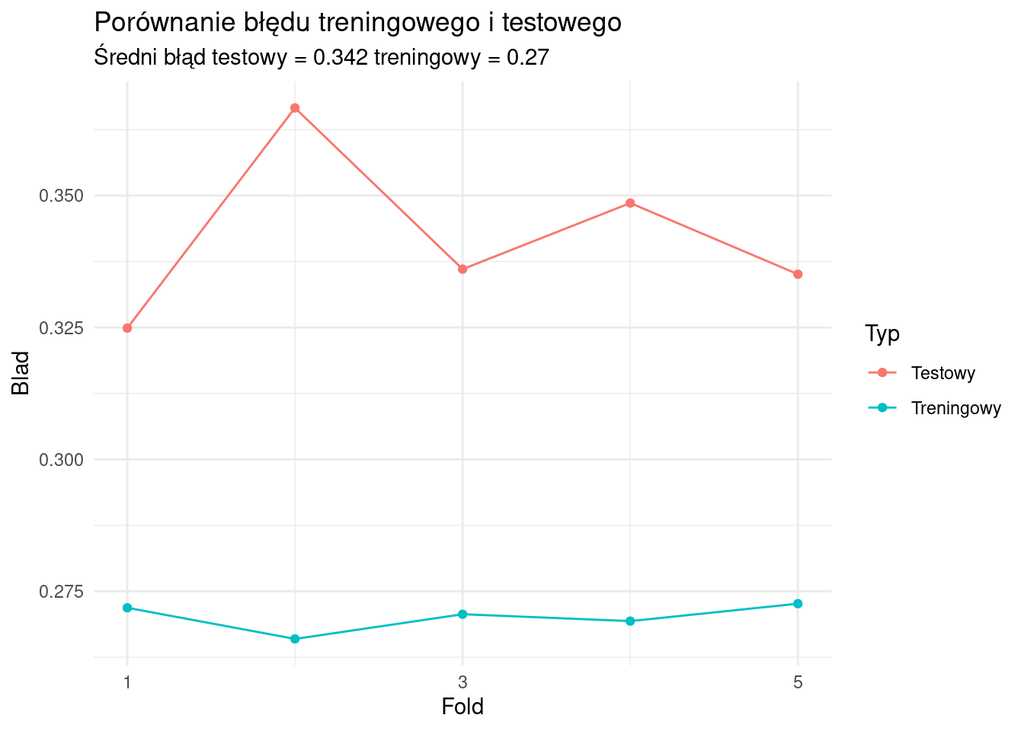

```r
library(ggplot2)
dane_do_wykresu <- data.frame('Fold' = as.integer(rep(1:x, 2)),
                              'Blad' = c(err.kfold, err.train),
                              'Typ' = rep(c('Testowy', 'Treningowy'), each=x))
ggplot(dane_do_wykresu,
       aes(x=Fold, y=Blad, color=Typ)) +
  ggtitle('Porównanie błędu treningowego i testowego',
          subtitle = paste0('Średni błąd testowy = ', round(matrix_parametrs_test_mean[chosen_alpha, chosen_lambda], 3), ' treningowy = ', round(matrix_parametrs_train_mean[chosen_alpha, chosen_lambda], 3))) +
  geom_line() + geom_point() + scale_x_continuous(breaks = seq(1,x,by=2)) +  theme_minimal()
```

Tak jak widać na załączonym wykresie błąd testowy wynosi 0.342, a treningowy 0.27.

#3. Random forest Poniżej porównamy działanie modelu random forest dla zadanej siatki parametrów i porówanymy jego działanie z modelem elastic net.

```r
library("ranger")
#function for testing hiperparameters
  train_and_test_random_forest <- function(x_train, y_train, train_set, param_vec){
  #parse vector of parameters
  num.trees = param_vec[1]
  max.depth = param_vec[2]
  alpha = param_vec[3]
  model <- ranger(x=x_train[train_set,,drop=TRUE],  y=y_train[train_set,], alpha = alpha, num.trees = num.trees, max.depth = max.depth)
  prediction <- predict(model, data=x_train)  # robimy predykcje na całych danych
  prediction_train <- prediction$predictions[train_set]  # wybieramy predykcje odpowiadające zbiorowi train_setmu
  prediction_test <- prediction$predictions[-train_set]
  #count RMSD and store result in matrix
  train_error <- sqrt(sum((prediction_train - y_train$CD36[train_set])^2)/length(train_set))
  test_error <- sqrt(sum((prediction_test - y_train$CD36[-train_set])^2)/(nrow(y_train)-length(train_set)))
  return(c(train_error, test_error))}
```

```r
#prepare grid of parameters
num.trees = c(5, 10, 50)
max.depth = c(10, 100, 500)
alpha = c(0.01, 0.1, 0.5)
grid<- as.matrix(expand.grid(num.trees, max.depth, alpha))
colnames(grid) <- c("num.trees", "max.depths", "alpha")
#here we will be deposing results from different folds
list_folds=list()
#test
for (i in 1:x) {
  train <- which(split != i)  #vector with indexes form train; the same as in elastic net task
  #here we are using parameters from grid
  result <- apply(grid, 1, train_and_test_random_forest, x_train = x_train, y_train=y_train, train_set = train)
  #reformat and save results
  result <- t(result)
  colnames(result)<- c("train_err", "test_err" )
  list_folds[[i]] <- cbind(grid, result)
  }
```

Poza modelami elastic net i random forest chcemy dołaczyć do ostatecznego porównania model referencyjny, który dla dowolnych zmiennych objaśniających przyporządkowuje średnią z zmiennej objaśnianej.

```r
#count reference model
ref_train_err_vec <- c()
ref_test_err_vec <-  c()
ref_fold_vec <- c()
for (i in 1:x) {
  train <- which(split != i)  #vector with indexes form train; the same as in elastic net task
  #count reference model
  mean_y_pred_train = rep(c(mean(y_train[train,])), each = length(train))
  mean_y_pred_test = rep(c(mean(y_train[train,])), each = length(y_train[-train,1]))
  #count errors
  ref_train_error <- sqrt(sum((mean_y_pred_train - y_train$CD36[train])^2)/length(train))
  ref_test_error <- sqrt(sum((mean_y_pred_test - y_train$CD36[-train])^2)/(nrow(y_train)-length(train)))
  #return(c(train_error, test_error))
  ref_train_err_vec <- append(ref_train_err_vec, ref_train_error)
  ref_test_err_vec <- append(ref_test_err_vec, ref_test_error)
  ref_fold_vec <- append(ref_fold_vec, i)
}
#count average
  ref_train_err_vec <- append(ref_train_err_vec, mean(ref_train_err_vec))
  ref_test_err_vec <- append(ref_test_err_vec, mean(ref_test_err_vec))
  ref_fold_vec <- c(ref_fold_vec, "average")
```

Aby porówanać modele musimy przygotować porówananie tabelaryczne, gdzie znajdą się wyniki dla poszczególnych podziałów (foldów) oraz wyniki uśrednione.

```r
#prepare table of comparison of different methods -
#results of random forest
param_string <- function(x, names){
  vec <-c()
  for (i in 1:length(names)){
  vec <- append(vec, names[[i]])
  vec <- append(vec, x[i])
  }
  res<-toString(vec)
  res
  }

parameters <- c()
method <- c()
fold <- c()
train_err <- c()
test_err <- c()
#random forest
for (i in 1:x){
  df_rf <- list_folds[[i]][,1:3]
  names <- as.vector(colnames(df_rf))
  param_vec <-apply(df_rf, 1, param_string, names)
  method_vec = rep(c("random_forest"), each = length(grid[,1]))
  fold_vec = rep (c(i), each = length(grid[,1]))
  train_err_vec <- list_folds[[i]][,"train_err"]
  test_err_vec <- list_folds[[i]][,"test_err"]
  parameters <- append(parameters, param_vec)
  method <- append(method, method_vec)
  fold <- append(fold, fold_vec)
  train_err <- append(train_err, train_err_vec)
  test_err <-  append(test_err, test_err_vec)
}

#add average results to table
#calculate average values
mean_folds <- Reduce("+", list_folds)/x
names <- as.vector(colnames(mean_folds[,1:3]))
param_vec <-apply(mean_folds[,1:3], 1, param_string, names)
train_err <- append(train_err, mean_folds[,"train_err"])
test_err <- append(test_err, mean_folds[,"test_err"])
parameters <- append(parameters, param_vec)
fold_vec = rep (c("average"), each = length(grid[,1]))
fold <- append(fold, fold_vec)
method_vec = rep(c("random_forest"), each = length(grid[,1]))
method <- append(method, method_vec)
```

```r
#add results from elastic net to table
alpha = c(0, 0.1, 0.5, 0.75)
lambda = c(0.001, 0.01, 0.1, 1)

for (i in 1:x){
  method_vec = rep(c("elastic_net"), each = length(alpha)*length(lambda))
  method <- append(method, method_vec)


  #add parameters

  for (a in  1:length(alpha)){
    for (l in 1:length(lambda)){
        train_err_vec <- list_folds_train[[i]][a, l]
        test_err_vec <- list_folds_test[[i]][a, l]
        train_err <- append(train_err, train_err_vec)
        test_err <-  append(test_err, test_err_vec)
        #add onew combination of parameters
        parameters <- append(parameters, param_string(c(alpha[a], lambda[l]), c("alpha", "lambda")))

      }
    }
  fold_vec = rep(c(i), each = length(alpha)*length(lambda)) #the lengh is the number of all parameters permutation
  fold <- append(fold, fold_vec)
  }
#add average results to table
for (a in  1:length(alpha)){
    for (l in 1:length(lambda)){
      train_err <- append(train_err, matrix_parametrs_train_mean[a,l])
      test_err <- append(test_err,matrix_parametrs_test_mean[a,l])
      parameters <- append(parameters, param_string(c(alpha[a], lambda[l]), c("alpha", "lambda")))
      fold <- append(fold, "average")
      method <- append(method, "elastic_net")
    }
  }

#add results from reference model
fold <- append(fold, ref_fold_vec)
train_err <- append(train_err, ref_train_err_vec)
test_err <- append(test_err, ref_test_err_vec)
parameters <- append(parameters, rep(c(NA), each=length(ref_fold_vec)))
method <- append(method, rep(c("reference_model"), each=length(ref_fold_vec)))

table = data.frame(fold, method, parameters, train_err, test_err)
table
```

| fold | method | parameters | train_err | test_err |
| --- | --- | --- | --- | --- |
| 1 | random_forest | num.trees, 5, max.depths, 10, alpha, 0.01 | 0.3074259716 | 0.3894263 |
| 1 | random_forest | num.trees, 10, max.depths, 10, alpha, 0.01 | 0.2868303544 | 0.3704968 |
| 1 | random_forest | num.trees, 50, max.depths, 10, alpha, 0.01 | 0.2656042898 | 0.3454279 |
| 1 | random_forest | num.trees, 5, max.depths, 100, alpha, 0.01 | 0.2101896465 | 0.3683836 |
| 1 | random_forest | num.trees, 10, max.depths, 100, alpha, 0.01 | 0.1795828195 | 0.3508382 |
| 1 | random_forest | num.trees, 50, max.depths, 100, alpha, 0.01 | 0.1489356549 | 0.3368435 |
| 1 | random_forest | num.trees, 5, max.depths, 500, alpha, 0.01 | 0.2053910248 | 0.3891694 |
| 1 | random_forest | num.trees, 10, max.depths, 500, alpha, 0.01 | 0.1777420428 | 0.3546517 |
| 1 | random_forest | num.trees, 50, max.depths, 500, alpha, 0.01 | 0.1511305881 | 0.3330702 |
| 1 | random_forest | num.trees, 5, max.depths, 10, alpha, 0.1 | 0.3027875035 | 0.3914799 |

[output cut: 254 more lines]

W celu wybrania najlepszego modelu porównamy wyniki uśrednione.

```r
avr_table <- table[which(table$fold == "average"),]
avr_table[order(avr_table$test_err),]
```

|  | fold | method | parameters | train_err | test_err |
| --- | --- | --- | --- | --- | --- |
| 249 | average | elastic_net | alpha, 0.1, lambda, 0.1 | 0.270095998 | 0.3422538 |
| 256 | average | elastic_net | alpha, 0.75, lambda, 0.01 | 0.241336841 | 0.3476582 |
| 162 | average | random_forest | num.trees, 50, max.depths, 500, alpha, 0.5 | 0.147127011 | 0.3497482 |
| 144 | average | random_forest | num.trees, 50, max.depths, 500, alpha, 0.01 | 0.148043021 | 0.3508917 |
| 153 | average | random_forest | num.trees, 50, max.depths, 500, alpha, 0.1 | 0.147728906 | 0.3514210 |
| 141 | average | random_forest | num.trees, 50, max.depths, 100, alpha, 0.01 | 0.147474907 | 0.3526864 |
| 159 | average | random_forest | num.trees, 50, max.depths, 100, alpha, 0.5 | 0.147873895 | 0.3530673 |
| 150 | average | random_forest | num.trees, 50, max.depths, 100, alpha, 0.1 | 0.148247391 | 0.3533248 |
| 252 | average | elastic_net | alpha, 0.5, lambda, 0.01 | 0.197035782 | 0.3576175 |
| 156 | average | random_forest | num.trees, 50, max.depths, 10, alpha, 0.5 | 0.259143684 | 0.3581245 |

[output cut: 34 more lines]

Zapiszemy predykcje dla najlepszego modelu elastic net i random forest.

```r
#elastic net
chosen_model_glmnet <- glmnet(x=x_train[train,,drop=TRUE],  y=y_train[train,], alpha =chosen_alpha, lambda = chosen_lambda)
y_pred_glmnet <- predict(chosen_model_glmnet, newx = as.matrix(x_test))
y_res_glmnet <- predict(chosen_model_glmnet, newx = as.matrix(x_train))
RMSD_train_glmnet <-  sqrt(sum((y_res_glmnet- y_train)^2))


#random forest
chosen_model_ranger <- ranger(x=x_train,  y=y_train$CD36, alpha = 0.5, num.trees = 50, max.depth = 500)
y_pred_random_forest <- predict(chosen_model_ranger, data=x_test)$predictions
y_res_random_forest <- predict(chosen_model_ranger, data=x_train)$predictions
RMSD_train_random_forest <-  sqrt(sum((y_res_random_forest- y_train)^2))
```

Biorąc pod uwagę najlepszy możliwy wynik należałoby wskazać elastic net jako lepszy model (dla parametrów alpha, 0.1, lambda, 0.1), natomiast za pomocą modelu random forest również osiągnięto wynik niewiele gorszy, Dla zadanej siatki hiperparametrów oba modelu są porównywalnie dobre.

## 4 Budowa modelu

Ponieważ mamy w danych bezpośrednio poziom rna kodującego białko CD36, to możemy domyślać się, że zmienna ta będzie miała największy wpływ na poziom białka CD36. Poniżej zwizualizowałam zależnoć rna kodującego białko CD36, a poziomem białka CD36. Choć trudno mówić to o konkretnym trendzie, to możemy bardzo zgrubnie zobaczyć trend linniowy, który ujwnia się trochę bardziej po transformacji logistycznej danych rna. Ta analiza sugeruję, że warto rozważyć transformacje logistyczną pozostałych zmiennych objaśnaich (które również opisuja poziom danego rna).

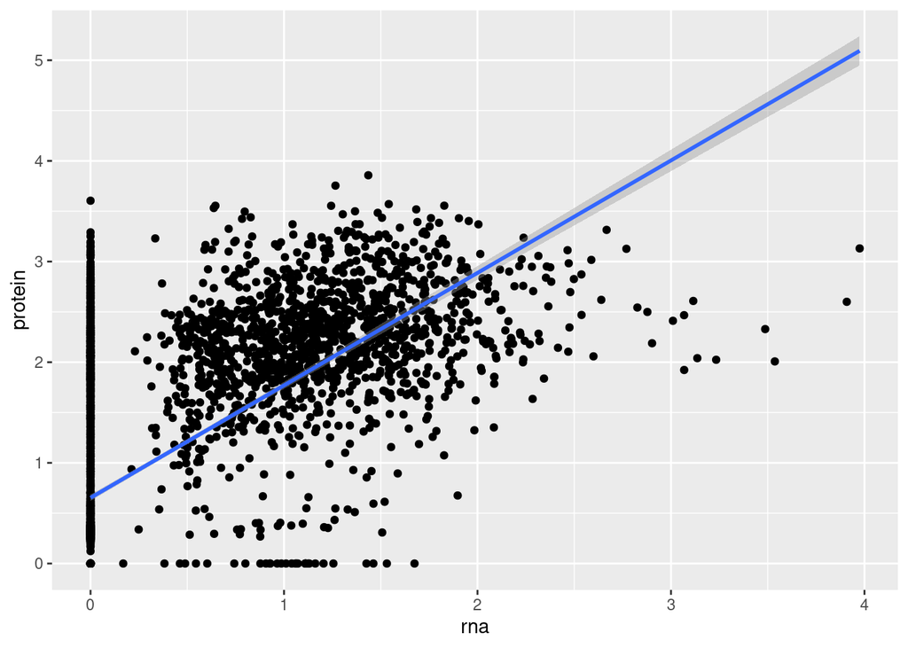

```r
df = data.frame(rna=x_train$CD36,protein = y_train$CD36)
ggplot(df, aes(x=rna, y=protein))+ geom_point() + geom_smooth(method=lm)
```

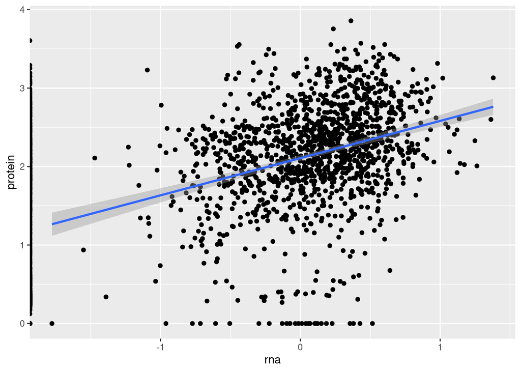

```r
df$rna <- log(df$rna)
ggplot(df, aes(x=rna, y=protein))+ geom_point() + geom_smooth(method=lm)
```

```r
#logistic data transformation
x_train_log <-apply(x_train, 2, log)
x_train_log[x_train_log == -Inf] <-0 #replace all -inf values to zero so they can be proceed in training
```

Ponieważ mamy bardzo dużo zmiennych możemy spróbować użyć regularyzacji lasso i przetestować ją na danych z i bez transformacji logistycznej.

```r
library(caret)
lassoGrid <- expand.grid(lambda = c(0.0001, 0.001, 0.01, 0.1, 1, 10, 100), alpha = c(1)) #alpha 1 -> lasso
train_control <- trainControl(method='cv', number=5)
lasso_kfold_train <- train(x=x_train_log, y=y_train$CD36, method = 'glmnet', trControl=train_control, tuneGrid =lassoGrid)
res_train <- predict(lasso_kfold_train, newdata = x_train_log)
x_test_log <-apply(x_test, 2, log)
x_test_log[x_test_log == -Inf]  <- 0 #to predict test we have to do the same transformation
res_test <- predict(lasso_kfold_train, newdata = x_test_log)
RMSD_train_lasso_log <- sqrt(sum((res_train- y_train)^2))
RMSD_test_lasso_log_mean <- mean(lasso_kfold_train$resample$RMSE)
```

```r
#check how model deal when there is no log transformation
library(caret)
lassoGrid <- expand.grid(lambda = c(0.0001, 0.001, 0.01, 0.1, 1, 10, 100), alpha = c(1)) #alpha 1 -> lasso
train_control <- trainControl(method='cv', number=5)
non_log_lasso_kfold_train <- train(x=x_train, y=y_train$CD36, method = 'glmnet', trControl=train_control, tuneGrid =lassoGrid)
res_train <- predict(non_log_lasso_kfold_train, newdata = x_train)
res_test <- predict(non_log_lasso_kfold_train, newdata = x_test)
#count RMSD on train set
RMSD_train_lasso <- sqrt(sum((res_train- y_train)^2))
RMSD_test_lasso_mean <- mean(non_log_lasso_kfold_train$resample$RMSE)
```

Biorąc pod uwagę wyniki RMSD dla obu wariantów danych (0.3711769 dla danych z transformacją logistyczną i 0.3474353 dla danych bez transformacji logistycznej), będę uczyć model na danych bez transformcji logistycznej.

```r
#check the resulted coefficients
coef_non_log_lasso <- as.matrix(coef(non_log_lasso_kfold_train$finalModel, s = non_log_lasso_kfold_train$bestTune$lambda))
how_many_coef <- sum(coef_non_log_lasso[,1] !=0)
```

Po zastosowaniu lasso w modelu utrzymaliśmy 599 współczynników.  
Porównajmy z wcześniejszym modelem glmnet.

```r
# model zbudowany na danych treningowych
coef_glmnet <- coef(chosen_model_glmnet)
how_many_coef_glmnet <- sum(coef_glmnet[,1] !=0)
```

```r
svd_rna <- svd(x_train)
V <- svd_rna$v
Sigma <- svd_rna$d
U <- svd_rna$u
```

```r
cumsum_pca <- cumsum(Sigma^2)/sum(Sigma^2)
cumsum_pca[1501:1750]
```

```
##   [1] 0.9211350 0.9212203 0.9213055 0.9213906 0.9214757 0.9215607 0.9216456
##   [8] 0.9217305 0.9218153 0.9219000 0.9219847 0.9220694 0.9221539 0.9222384
##  [15] 0.9223228 0.9224071 0.9224913 0.9225754 0.9226595 0.9227435 0.9228274
##  [22] 0.9229112 0.9229950 0.9230787 0.9231623 0.9232458 0.9233293 0.9234128
##  [29] 0.9234961 0.9235794 0.9236626 0.9237457 0.9238287 0.9239117 0.9239946
##  [36] 0.9240774 0.9241602 0.9242428 0.9243254 0.9244079 0.9244903 0.9245727
##  [43] 0.9246550 0.9247373 0.9248195 0.9249016 0.9249836 0.9250656 0.9251475
##  [50] 0.9252293 0.9253111 0.9253928 0.9254744 0.9255560 0.9256374 0.9257188
##  [57] 0.9258000 0.9258812 0.9259624 0.9260434 0.9261243 0.9262052 0.9262860
##  [64] 0.9263668 0.9264476 0.9265283 0.9266089 0.9266895 0.9267699 0.9268503
##  [71] 0.9269306 0.9270109 0.9270910 0.9271710 0.9272510 0.9273309 0.9274108
##  [78] 0.9274905 0.9275702 0.9276499 0.9277295 0.9278090 0.9278885 0.9279680
##  [85] 0.9280472 0.9281265 0.9282056 0.9282847 0.9283637 0.9284427 0.9285216
##  [92] 0.9286005 0.9286793 0.9287580 0.9288367 0.9289153 0.9289939 0.9290724
##  [99] 0.9291508 0.9292291 0.9293074 0.9293857 0.9294638 0.9295419 0.9296199
```

[output cut: 21 more lines]

Możemy zauważyć, że dopiero wzięcie piewszych 1747 składowych pozwoli nam na osiągnięcie wariancji na poziomie 94%. Dlatego spróbujemy innego podejścia.

W celu zbudowania dobrego modelu chcemy się pozbyć wysoko skorelowanych zmiennych. W tym celu potraktujemy korelacje jako odległość między genami, a następnie sklastrujemy je hierarchicznie. W tym celu uwzględnimy tylko 250 o największej i najmniejszej korealcji ze zmienną objaśnianą, czyli takie które są silnie skorelowane pozytywnie lub negatywnie.

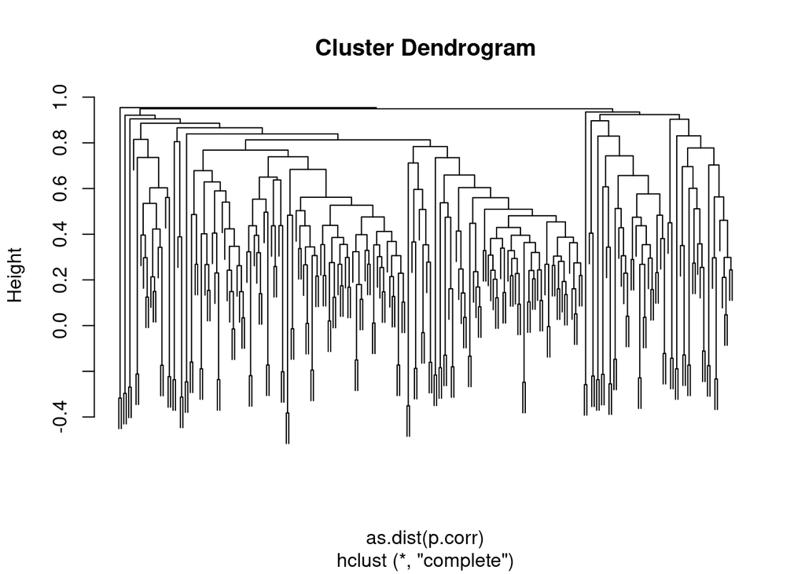

```r
corr_matrix<-cor(x_train)
#find variables which correlation is above 80% but less then 100% - we dont want include self correlation
selected <- which(corr_matrix > 0.8 & corr_matrix < 1, arr.ind = T)
#we want to save only one of each clusters of highly correlated values
# we have to decrease number of data
# lets analyse only those with high (positive and negative correlation)
order_corr <- unlist(order(corr, decreasing=TRUE))[1:250]
p.corr <- cor(x_train[,order_corr])
cor.tree <- hclust(as.dist(p.corr))
plot(cor.tree, cex = 0.00002)
order_corr_neg <- unlist(order(corr, decreasing=FALSE))[1:250]
p.corr.neg <- cor(x_train[,order_corr_neg])
cor.neg.tree <- hclust(as.dist(p.corr.neg))
plot(cor.tree, cex = 0.00002)
```

```r
#cuttrees
k1 = 25
clusters.cor <- cutree(cor.tree, k=k1)
k2 = 30
clusters.cor.neg <- cutree(cor.neg.tree, k=k2)
#choose one from each cluster
clusters.df <- data.frame(gene = names(clusters.cor), cluster = clusters.cor)
clusters.df.neg <- data.frame(gene = names(clusters.cor.neg), cluster = clusters.cor.neg)
vec_genes_name <- c()
for (i in 1:k1){
  cluster.gene <- clusters.df[which(clusters.df$cluster == i),]$gene[1] #take first
  vec_genes_name <- append(vec_genes_name, cluster.gene)
  }

neg_vec_genes_name <- c()
for (i in 1:k2){
  cluster.gene <- clusters.df.neg[which(clusters.df.neg$cluster == i),]$gene[1] #take first
  neg_vec_genes_name <- append(neg_vec_genes_name, cluster.gene)
}
#chosen
vec_genes_name <- append(vec_genes_name, neg_vec_genes_name)
new_x_train <- x_train[, vec_genes_name]
new_x_test <- x_test[, vec_genes_name]
```

1. Elastic net

```r
train_control <- trainControl(method='cv', number=5)
grid_glmnet <- expand.grid(lambda=lambda, alpha=alpha)
glm_kfold_train <- train(x=new_x_train, y=y_train$CD36, method = 'glmnet', trControl=train_control, tuneGrid = grid_glmnet)
glm_res_train <- predict(glm_kfold_train, newdata = new_x_train)
#calculate glm on x test
glm_res_test <- predict(glm_kfold_train, newdata = new_x_test)
#count RMSD on train set
RMSD_train_glm <- sqrt(sum((glm_res_train- y_train)^2))
RMSD_test_glm_mean <- mean(lasso_kfold_train$resample$RMSE)
```

2. Random forest

```r
train_control <- trainControl(method='cv', number=5)
grid_rf <- expand.grid(mtry= c(1, 2, 3, 4, 5, 7, 8, 10, 15, 50), splitrule = c("extratrees"), min.node.size = c(1, 2, 3, 4, 5,10))
rf_selected_kfold_train <- train(x=new_x_train, y=y_train$CD36, method = 'ranger', trControl=train_control, tuneGrid = grid_rf)
glm_res_train <- predict(glm_kfold_train, newdata = new_x_train)
#calculate PCA on x test
rf_res_test <- predict(glm_kfold_train, newdata = new_x_test)
RMSD_train_rf <- sqrt(sum((glm_res_train- y_train)^2))
RMSD_test_rf_selected_mean <- mean(rf_selected_kfold_train$resample$RMSE)
```